# 山东黄金 (600547.SH) 涨跌分类模型

## 1. 导入依赖库

```python
import tushare as ts
import pandas as pd
import numpy as np
import matplotlib.pyplot as plt
import seaborn as sns
import warnings
warnings.filterwarnings("ignore")

from sklearn.linear_model import LogisticRegression
from sklearn.tree import DecisionTreeClassifier, plot_tree
from sklearn.ensemble import RandomForestClassifier
from sklearn.preprocessing import StandardScaler
from sklearn.metrics import (
    accuracy_score, precision_score, recall_score,
    f1_score, confusion_matrix, roc_auc_score, roc_curve,
    classification_report
)

# 设置 matplotlib 中文字体
plt.rcParams.update({
    "font.family": "Microsoft YaHei",
    "font.size": 10,
    "axes.unicode_minus": False,
    "figure.dpi": 150,
    "savefig.dpi": 150,
})

print("\u2705 依赖库导入成功")
```

```
✅ 依赖库导入成功
```

## 2. 获取数据

从 Tushare Pro 拉取 600547.SH（山东黄金）的日线行情数据。

```python
# Tushare 初始化
ts.set_token(''***REDACTED***'')
pro = ts.pro_api()

# 获取日线数据
df = pro.daily(ts_code='600547.SH', start_date='20140101', end_date='20260713')
df = df.sort_values('trade_date').reset_index(drop=True)
df['trade_date'] = pd.to_datetime(df['trade_date'])

# 重命名列为英文
df.rename(columns={
    'open': 'Open', 'high': 'High', 'low': 'Low',
    'close': 'Close', 'vol': 'Volume', 'amount': 'Amount'
}, inplace=True)

print(f"\u2705 数据获取成功: {len(df)} 条记录")
print(f"\U0001f4c5 时间范围: {df["trade_date"].iloc[0].date()} ~ {df["trade_date"].iloc[-1].date()}")
print(f"\U0001f522 列: {list(df.columns)}")
df[['trade_date','Open','High','Low','Close','Volume']].head()
```

```
✅ 数据获取成功: 2929 条记录
📅 时间范围: 2014-01-02 ~ 2026-07-13
🔢 列: ['ts_code', 'trade_date', 'Open', 'High', 'Low', 'Close', 'pre_close', 'change', 'pct_chg', 'Volume', 'Amount']
```

|  | trade_date | Open | High | Low | Close | Volume |
| --- | --- | --- | --- | --- | --- | --- |
| 0 | 2014-01-02 | 17.52 | 18.35 | 17.52 | 18.05 | 199551.94 |
| 1 | 2014-01-03 | 18.10 | 18.26 | 17.95 | 18.06 | 91680.14 |
| 2 | 2014-01-06 | 18.07 | 18.20 | 17.35 | 17.48 | 84964.65 |
| 3 | 2014-01-07 | 17.40 | 17.49 | 17.24 | 17.35 | 58158.74 |
| 4 | 2014-01-08 | 17.25 | 17.29 | 16.62 | 16.67 | 122274.68 |

## 3. 构造标签 (Label)

**规则**：

- Label[i] = 1：第 i+1 日收盘价 > 第 i 日收盘价（**涨**）
- Label[i] = 0：第 i+1 日收盘价 ≤ 第 i 日收盘价（**跌**）

使用 shift(-1) 将未来一天的涨跌信息对齐到当天。

```python
# 构造标签：下一日收盘价 > 今日收盘价 → 1（涨），否则 → 0（跌）
df['Label'] = (df['Close'].shift(-1) > df['Close']).astype(int)

# 统计分布
label_counts = df['Label'].value_counts()
print(f"\U0001f4ca 标签分布:")
print(f"   涨 (1): {label_counts.get(1, 0)} 条 ({df["Label"].mean():.2%})")
print(f"   跌 (0): {label_counts.get(0, 0)} 条 ({1 - df["Label"].mean():.2%})")
print(f"   总样本: {len(df)} 条（含最后一行 NaN，后续会被 dropna 去除）")
```

```
📊 标签分布:
   涨 (1): 1459 条 (49.81%)
   跌 (0): 1470 条 (50.19%)
   总样本: 2929 条（含最后一行 NaN，后续会被 dropna 去除）
```

## 4. 特征工程

构建 13 个基础特征，分为 5 组：

| 分组 | 特征 | 说明 |
| --- | --- | --- |
| (A) 滞后收益率 | ret_1d, ret_2d, ret_3d, ret_5d | 过去1/2/3/5日收益率 |
| (B) 价格波动 | range_pct, intraday_chg | 日内波幅占比、日内涨跌幅 |
| (C) 成交量 | volume_chg, volume_ratio_5d | 成交量变化率、量比(5日均量) |
| (D) 滚动统计 | close_ma5, close_std5, close_vs_ma5 | 5日均线、标准差、偏离度 |
| (E) 日历特征 | month, dayofweek | 月份(季节性)、星期(周内效应) |

```python
# --- (A) 滞后收益率 ---
df['ret_1d'] = df['Close'].pct_change(1)
df['ret_2d'] = df['Close'].pct_change(2)
df['ret_3d'] = df['Close'].pct_change(3)
df['ret_5d'] = df['Close'].pct_change(5)

# --- (B) 价格波动特征 ---
df['range_pct'] = (df['High'] - df['Low']) / df['Close']
df['intraday_chg'] = (df['Close'] - df['Open']) / df['Open']

# --- (C) 成交量特征 ---
df['volume_chg'] = df['Volume'].pct_change(1)
df['volume_ratio_5d'] = df['Volume'] / df['Volume'].rolling(5).mean()

# --- (D) 滚动统计特征 ---
df['close_ma5'] = df['Close'].rolling(5).mean()
df['close_std5'] = df['Close'].rolling(5).std()
df['close_vs_ma5'] = (df['Close'] - df['close_ma5']) / df['close_ma5']

# --- (E) 日历特征 ---
df['month'] = df['trade_date'].dt.month
df['dayofweek'] = df['trade_date'].dt.dayofweek

feature_cols = [
    'ret_1d', 'ret_2d', 'ret_3d', 'ret_5d',
    'range_pct', 'intraday_chg',
    'volume_chg', 'volume_ratio_5d',
    'close_ma5', 'close_std5', 'close_vs_ma5',
    'month', 'dayofweek'
]
print(f"\u2705 特征工程完成，共构建 {len(feature_cols)} 个特征:")
for i, col in enumerate(feature_cols, 1):
    print(f"   {i:2d}. {col}")
```

```
✅ 特征工程完成，共构建 13 个特征:
    1. ret_1d
    2. ret_2d
    3. ret_3d
    4. ret_5d
    5. range_pct
    6. intraday_chg
    7. volume_chg
    8. volume_ratio_5d
    9. close_ma5
   10. close_std5
   11. close_vs_ma5
   12. month
   13. dayofweek
```

## 5. 数据预处理

```python
# 清除 NaN
df_clean = df.dropna().reset_index(drop=True)

# 时间划分
train = df_clean[df_clean['trade_date'] < '2024-01-01'].copy()
test  = df_clean[df_clean['trade_date'] >= '2024-01-01'].copy()

print(f"\U0001f4ca 数据集划分结果:")
print(f"   训练集: {len(train)} 条")
print(f"       时间: {train["trade_date"].iloc[0].date()} ~ {train["trade_date"].iloc[-1].date()}")
print(f"       上涨比例: {train["Label"].mean():.2%}")
print(f"   测试集: {len(test)} 条")
print(f"       时间: {test["trade_date"].iloc[0].date()} ~ {test["trade_date"].iloc[-1].date()}")
print(f"       上涨比例: {test["Label"].mean():.2%}")
```

```
📊 数据集划分结果:
   训练集: 2314 条
       时间: 2014-01-09 ~ 2023-12-29
       上涨比例: 50.00%
   测试集: 610 条
       时间: 2024-01-02 ~ 2026-07-13
       上涨比例: 49.34%
```

## 6. 模型训练

### 模型配置

| 模型 | 关键参数 | 需标准化 |
| --- | --- | --- |
| 逻辑回归 | C=1.0, max_iter=1000 | [OK] 是（StandardScaler） |
| 决策树 | max_depth=5, min_samples_leaf=10 | ❌ 否（树模型不受尺度影响） |
| 随机森林 | n_estimators=100, max_depth=8, min_samples_leaf=5 | ❌ 否 |

```python
# 准备特征矩阵
X_train = train[feature_cols].values
y_train = train['Label'].values
X_test  = test[feature_cols].values
y_test  = test['Label'].values

# 标准化（仅逻辑回归需要）
scaler = StandardScaler()
X_train_scaled = scaler.fit_transform(X_train)
X_test_scaled  = scaler.transform(X_test)

print(f"特征矩阵维度 — 训练集: {X_train.shape}, 测试集: {X_test.shape}")
```

```
特征矩阵维度 — 训练集: (2314, 13), 测试集: (610, 13)
```

```python
# 定义模型
models = {
    "Logistic Regression": LogisticRegression(
        C=1.0, max_iter=1000, random_state=42
    ),
    "Decision Tree": DecisionTreeClassifier(
        max_depth=5, min_samples_leaf=10, random_state=42
    ),
    "Random Forest": RandomForestClassifier(
        n_estimators=100, max_depth=8, min_samples_leaf=5,
        random_state=42, n_jobs=-1
    )
}

# 训练 & 预测
results = {}
for name, model in models.items():
    if name == "Logistic Regression":
        model.fit(X_train_scaled, y_train)
        y_pred = model.predict(X_test_scaled)
        y_prob = model.predict_proba(X_test_scaled)[:, 1]
    else:
        model.fit(X_train, y_train)
        y_pred = model.predict(X_test)
        y_prob = model.predict_proba(X_test)[:, 1]

    results[name] = {"y_pred": y_pred, "y_prob": y_prob, "model": model}
    print(f"\u2705 {name} 训练完成")
```

```
✅ Logistic Regression 训练完成
✅ Decision Tree 训练完成
```

```
✅ Random Forest 训练完成
```

## 7. 模型评估

| 指标 | 说明 |
| --- | --- |
| Accuracy | 整体准确率 |
| Precision | 预测为涨的样本中，实际为涨的比例 |
| Recall | 实际为涨的样本中，被正确预测的比例 |
| F1-score | Precision 与 Recall 的调和平均 |
| ROC AUC | 模型区分能力（基于预测概率） |

```python
for name, res in results.items():
    y_pred = res['y_pred']
    y_prob = res['y_prob']

    acc  = accuracy_score(y_test, y_pred)
    prec = precision_score(y_test, y_pred)
    rec  = recall_score(y_test, y_pred)
    f1   = f1_score(y_test, y_pred)
    roc  = roc_auc_score(y_test, y_prob) if y_prob is not None else 'N/A'

    print(f"{'='*50}")
    print(f'  {name}')
    print(f"{'='*50}")
    print(f'  Accuracy : {acc:.4f}')
    print(f'  Precision: {prec:.4f}')
    print(f'  Recall   : {rec:.4f}')
    print(f'  F1-score : {f1:.4f}')
    print(f'  ROC AUC  : {roc:.4f}')
    print()
    print(classification_report(y_test, y_pred, target_names=['\u8dcc(0)', '\u6da8(1)']))
```

```
==================================================
  Logistic Regression
==================================================
  Accuracy : 0.5082
  Precision: 0.5015
  Recall   : 0.5382
  F1-score : 0.5192
  ROC AUC  : 0.5189

              precision    recall  f1-score   support

        跌(0)       0.52      0.48      0.50       309
        涨(1)       0.50      0.54      0.52       301

    accuracy                           0.51       610
   macro avg       0.51      0.51      0.51       610
weighted avg       0.51      0.51      0.51       610

==================================================
  Decision Tree
==================================================
  Accuracy : 0.5213
  Precision: 0.5164
  Recall   : 0.4718
  F1-score : 0.4931
  ROC AUC  : 0.5063

              precision    recall  f1-score   support

        跌(0)       0.53      0.57      0.55       309
        涨(1)       0.52      0.47      0.49       301

    accuracy                           0.52       610
   macro avg       0.52      0.52      0.52       610
weighted avg       0.52      0.52      0.52       610

==================================================
  Random Forest
==================================================
  Accuracy : 0.5131
  Precision: 0.5067
  Recall   : 0.5017
  F1-score : 0.5042
  ROC AUC  : 0.5159

              precision    recall  f1-score   support

        跌(0)       0.52      0.52      0.52       309
        涨(1)       0.51      0.50      0.50       301

    accuracy                           0.51       610
   macro avg       0.51      0.51      0.51       610
weighted avg       0.51      0.51      0.51       610
```

## 8. 混淆矩阵可视化

三个模型的混淆矩阵并排对比。

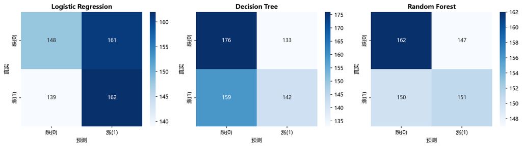

```python
fig, axes = plt.subplots(1, 3, figsize=(14, 4))
for ax, (name, res) in zip(axes, results.items()):
    cm = confusion_matrix(y_test, res['y_pred'])
    sns.heatmap(cm, annot=True, fmt='d', cmap='Blues', ax=ax,
                xticklabels=['\u8dcc(0)', '\u6da8(1)'], yticklabels=['\u8dcc(0)', '\u6da8(1)'])
    ax.set_title(name, fontsize=12, fontweight='bold')
    ax.set_xlabel('\u9884\u6d4b')
    ax.set_ylabel('\u771f\u5b9e')
plt.tight_layout()
plt.show()
```

## 9. ROC 曲线

展示逻辑回归和随机森林的 ROC 曲线及 AUC 值。

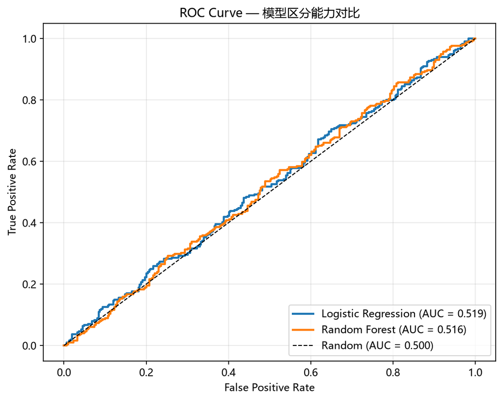

```python
plt.figure(figsize=(8, 6))

for name in ["Logistic Regression", "Random Forest"]:
    y_prob = results[name]['y_prob']
    if y_prob is not None:
        fpr, tpr, _ = roc_curve(y_test, y_prob)
        auc_val = roc_auc_score(y_test, y_prob)
        plt.plot(fpr, tpr, lw=2, label=f'{name} (AUC = {auc_val:.3f})')

# 随机基准线
plt.plot([0, 1], [0, 1], "k--", lw=1, label="Random (AUC = 0.500)")

plt.xlabel("False Positive Rate")
plt.ylabel("True Positive Rate")
plt.title("ROC Curve — 模型区分能力对比")
plt.legend(loc="lower right")
plt.grid(alpha=0.3)
plt.show()
```

## 10. 特征重要性 (Decision Tree & Random Forest)

树模型内置的 feature_importances_ 属性展示各特征对预测的贡献度。

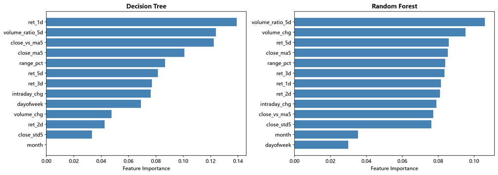

```python
fig, axes = plt.subplots(1, 2, figsize=(14, 5))

for ax, name in zip(axes, ["Decision Tree", "Random Forest"]):
    model = results[name]['model']
    importances = model.feature_importances_
    indices = np.argsort(importances)[::-1]

    ax.barh(range(len(indices)), importances[indices], color="steelblue")
    ax.set_yticks(range(len(indices)))
    ax.set_yticklabels([feature_cols[i] for i in indices])
    ax.set_xlabel("Feature Importance")
    ax.set_title(name, fontsize=12, fontweight='bold')
    ax.invert_yaxis()

plt.tight_layout()
plt.show()
```

## 11. 决策树可视化 (简化版)

用 max_depth=3 重新训练一颗浅决策树，便于直观理解树的分裂逻辑。

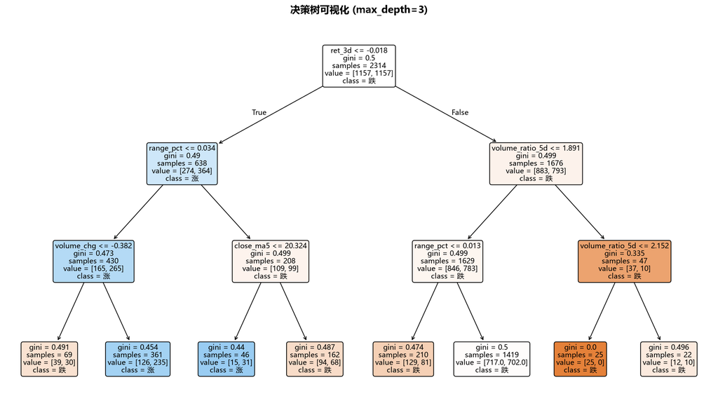

```python
# 重新训练一颗浅决策树用于可视化
dt_small = DecisionTreeClassifier(max_depth=3, random_state=42)
dt_small.fit(X_train, y_train)

plt.figure(figsize=(18, 10))
plot_tree(
    dt_small,
    feature_names=feature_cols,
    class_names=['\u8dcc', '\u6da8'],
    filled=True,
    rounded=True,
    fontsize=10
)
plt.title('\u51b3\u7b56\u6811\u53ef\u89c6\u5316 (max_depth=3)', fontsize=14, fontweight='bold')
plt.show()
```

## 12. 结论与总结

### 模型对比

[output not shown]

### 可能的改进方向

- 引入更多技术指标（RSI, MACD, 布林带等）
- 尝试 XGBoost / LightGBM 等集成模型
- 超参数调优（GridSearchCV / RandomizedSearchCV）
- 特征筛选与降维
- 引入外部因素（美元指数、黄金期货、宏观经济数据）